# Jordan Lake Reservoir Model

Part4: Developing a random forest model to predict the bottom to surface P ratios

Smitom Borah

04/25/2023

Time required to run the entire notebook: ~10 secs

# 1 Motivation

In this notebook, we developed a random forest model that can be used to predict bottom to surface P ratio that is used to calculate the surface P concentration in the Jordan lake model. Most of the codes in this notebook is similar to the codes written in the notebook, *Additional025_Stratification_v02082022.Rmd*.

# 2 Edit log

*No new edit since its creation.*

# 3 Introduction

In this notebook, we develop the random forest model and visualize its performance in different segments. The random forest model was developed based on the following features:

1. Average wind speed (m/s)
2. 5weeks M.A. air temperature ($^\circ C$)
3. 2weeks M.A. air temperature ($^\circ C$)
4. Surface sampling depths (m)
5. Bottom sampling depths (m)
6. Month
7. Segment

We also calculate the seasonal median with the simulated bottom to surface P ratio for the period 1983-2018.

```r
# Clearing the environment----
cat("\014"); rm(list=ls(all=TRUE)); graphics.off()
```

```r
# Start timer
Start_timer4 <- Sys.time()

# loading the required packages
library(tidyverse)
library(readxl)
library(lubridate)
library(FNN)
library(gridExtra)
library(kableExtra)
library(caret)
library(randomForest)
library(zoo)
library(plotly)

# Loading functions script created by Dario
# suppressMessages(source("Pmodels/functionsJorLak_no19.R"))
suppressMessages(source("Pmodels/JLPMfunv16p001.R"))
```

# 4 Data

## 4.1 Temperature data

The temperature data is stored in the files: - *Sim_SurfaceWaterTemp_daily.csv* for surface temperature - *Sim_BottomWaterTemp_daily.csv* for bottom temperature

```r
# Adding temperature data
## Simulated surface water temperature
Sim_SurTemp <- read.csv("DataFiles/Sim_SurfaceWaterTemp_daily.csv") %>% drop_na()

Sim_SurTemp <- Sim_SurTemp[,c("Date","Airtemp","AirTmp_14d", "WtrTemp_14d")]
Sim_SurTemp$Date <- as.Date(Sim_SurTemp$Date)

# Final data frame with daily 14 day M.A. air temperature
# (as substitute for surface water temperature)
Sim_SurTemp <- rename(Sim_SurTemp, AirTemp = Airtemp, SurfaceTemp = AirTmp_14d)

## Simulated bottom water temperature
Sim_BotTemp <- read.csv("DataFiles/Sim_BottomWaterTemp_daily.csv") %>% drop_na()

Sim_BotTemp <- Sim_BotTemp[,c("Date","AirTmp_35d", "WtrTemp_35d")]
Sim_BotTemp$Date <- as.Date(Sim_BotTemp$Date, format = "%m/%d/%Y")

# Final data frame with daily 35 day M.A. air temperature
# (as substitute for bottom water temperature)
Sim_BotTemp <- rename(Sim_BotTemp, BottomTemp = AirTmp_35d)
```

## 4.2 Wind data

Wind data was collected from KRDU airport. The data is stored in *RDU_windspeed.xlsx* in *DataFiles* folder.

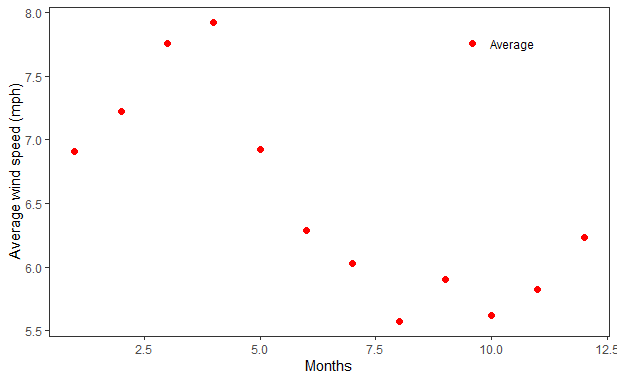

```r
# Download the wind data
RDU_wind <- read_excel("DataFiles/RDU_windspeed.xlsx", range = "A13:C13892")

# Making date column a date-time object
RDU_wind$Date <- as.Date(RDU_wind$Date)

# Monthly wind-speed
## Average
RDU_wind_avg_mo <- RDU_wind %>% drop_na() %>%
  mutate(Month = month(Date)) %>%
  group_by(Month)%>%
  summarise(Avg_speed = mean(`Average Wind Speed (mph)`))

## Visualizing monthly windspeed
ggplot(data = RDU_wind_avg_mo)+
  geom_point(aes(x = Month, y = Avg_speed, color = "Average"), size = 2)+
  theme_bw()+
  theme(legend.background = element_blank(),
        panel.grid.major = element_blank(),
        panel.grid.minor = element_blank(),
        legend.position = c(0.8,0.9),
        legend.title = element_blank())+
  scale_color_manual(values = (c(`Average` = "red")))+
  labs(x = "Months",
       y = "Average wind speed (mph)")
```

## 4.3 P data

The P data is loaded from the following files:

1. Segment 2: *Segment2_Pdata.xlsx*
2. Segment 3: *Segment3_Pdata.xlsx*
3. Segment 4: *Segment4_Pdata.xlsx*

These files are present in the *DataFiles* folder.

```r
# Function to automate the data collection process
CollectData <- function(FileName = "Segment2_Pdata.xlsx", SheetName = "report"){
  ## Loading the raw file
  Fname <- paste0("DataFiles/",FileName)
  Seg_Praw <- read_excel(Fname, sheet = SheetName)
  Seg_P <- Seg_Praw[,c("ActivityStartDate",
                       "ActivityStartTime/Time",
                       "ActivityDepthHeightMeasure/MeasureValue",
                       "ActivityDepthHeightMeasure/MeasureUnitCode",
                       "CharacteristicName",
                       "ResultSampleFractionText",
                       "ResultMeasureValue",
                       "ResultMeasure/MeasureUnitCode",
                       "MonitoringLocationIdentifier",
                       "USGSPCode",
                       "ResultAnalyticalMethod/MethodName",
                       "MethodDescriptionText")]

  ## renaming the columns
  colnames(Seg_P) <- c("Date","Time","Depth","Depth_unit","P_type", "P_fraction", "P_conc",
                        "P_unit","Site","Code","MethodName","MethodDesc")
  ## make date a DateTime Object
  Seg_P$Date <- as.Date(Seg_P$Date, format = "%Y-%m-%d")

  ## Changing characters to numeric
  Seg_P[,c("Depth","P_conc")] <- apply(Seg_P[,c("Depth","P_conc")], 2, as.numeric)

  ## Change unit for depth to m
  Seg_P$Depth[which(Seg_P$Depth_unit=="ft")] <- Seg_P$Depth[which(Seg_P$Depth_unit=="ft")]*0.3048
  Seg_P$Depth_unit[which(Seg_P$Depth_unit=="ft")] <-"m"
  Seg_P$Depth_unit[which(Seg_P$Depth_unit=="meters")] <-"m"

  ## Removing the dissolved P from the tables
  Seg_P <- Seg_P[which(Seg_P$P_fraction=="Total"),]

  ## adding a column for month
  Seg_P <- Seg_P %>% mutate(Month = month(Date))

  ## Separating into surface and bottom P concentraiton
  ## if Depth <= 3 m -> Surface P concentration
  ## if Depth > 3 m -> Bottom P concentration

  ## Adding a column to classify the P as surface or bottom P
  Seg_P <- Seg_P %>% mutate(P_location = ifelse(Depth<=3,"surface","Bottom"))

  ## Option 1: Selecting only depth, monitoring site and P concentration from Seg_P
  # Seg_Pdat <- Seg_P[,c("Date","Site","P_location", "P_conc", "Depth" )] %>% drop_na()

  ## Option 2: Selecting only depth and P concentration from Seg_P
  Seg_Pdat <- Seg_P[,c("Date","P_location", "P_conc", "Depth" )] %>% drop_na()

  ## Removing diurnal variability
  # Seg_Pdat <- Seg_Pdat %>% group_by(Date,Site, P_location) %>% summarise_at(.vars = c("P_conc", "Depth"), .funs = median)
  Seg_Pdat <- Seg_Pdat %>% group_by(Date, P_location) %>% summarise_at(.vars = c("P_conc", "Depth"), .funs = mean)

  ## Spreading the data
  ## Option 1:
  # Seg_Pdat <- pivot_wider(data = Seg_Pdat,
  #             id_cols = c(Date,Site),
  #             names_from = P_location,
  #             values_from = c("P_conc", "Depth")) %>% drop_na()

  ## Option 2:
  Seg_Pdat <- pivot_wider(data = Seg_Pdat,
                         id_cols = c(Date),
                         names_from = P_location,
                         values_from = c("P_conc", "Depth")) %>%
    drop_na()

  # Adding wind data to the segment phosphorus data
  Seg_Pdat <- merge(Seg_Pdat, RDU_wind, by = "Date", all.x = T)

  ## Merging temperature data
  Seg_Pdat <- merge(Seg_Pdat, Sim_SurTemp, by = "Date" )
  Seg_Pdat <- merge(Seg_Pdat, Sim_BotTemp, by = "Date" )

  ## Absolute difference between bottom and surface measured depth
  Seg_Pdat <- Seg_Pdat %>% mutate(TempDiff = abs(SurfaceTemp-BottomTemp))

  ## Calculating bottom to surface P ratio
  Seg_Pdat <- Seg_Pdat%>% mutate(BoSuP = P_conc_Bottom/P_conc_surface)

  ## difference between bottom and surface measured depth
  Seg_Pdat<- Seg_Pdat %>% mutate(level_diff = Depth_Bottom-Depth_surface,
                                      Bottom_level_diff = Depth_Bottom-3)

  ## adding a column for month
  Seg_Pdat <- Seg_Pdat %>% mutate(Month = month(Date),
                                  Year = year(Date),
                                  Segment = parse_number(strsplit(FileName, split = "_")[[1]][1]))


  return(list(Seg_Praw, Seg_P, Seg_Pdat))
}

#===============================================
## test
# Seg.x_P <- CollectData()
# Segx_Praw <- Seg.x_P[[1]]
# Segx_P <- Seg.x_P[[2]]
# Segx_Pdat <- Seg.x_P[[3]]
```

### 4.3.1 Segment 2

```r
# Collecting P data from Segment 2
Seg.2_P <- CollectData("Segment2_Pdata.xlsx","report")
Seg2_Praw <- Seg.2_P[[1]]
Seg2_P <- Seg.2_P[[2]]
Seg2_Pdat <- Seg.2_P[[3]]

# Segment 2 data frame
head(Seg2_Pdat, n = nrow(Seg2_Pdat))
```

|  | Date | P_conc_Bottom | P_conc_surface | Depth_Bottom | Depth_surface | Average Wind Speed (mph) | Maximum Wind Speed (mph) | AirTemp | SurfaceTemp | WtrTemp_14d | BottomTemp | WtrTemp_35d | TempDiff | BoSuP | level_diff | Bottom_level_diff | Month | Year | Segment |
| --- | --- | --- | --- | --- | --- | --- | --- | --- | --- | --- | --- | --- | --- | --- | --- | --- | --- | --- | --- |
| 1 | 1982-07-14 | 0.29000000 | 0.07000000 | 5.486400 | 1.219200 | 4.3 | 11.5 | 24.6 | 24.778571 | 27.654174 | 23.9942857 | 23.842053 | 0.78428572 | 4.1428571 | 4.267200 | 2.486400 | 7 | 1982 | 2 |
| 2 | 1982-08-10 | 0.21000000 | 0.06000000 | 3.962400 | 0.100584 | 6.9 | 9.2 | 25.3 | 25.221429 | 28.103046 | 25.6628571 | 25.315735 | 0.44142857 | 3.5000000 | 3.861816 | 0.962400 | 8 | 1982 | 2 |
| 3 | 1982-10-04 | 0.05000000 | 0.09000000 | 19.812000 | 0.762000 | 4.1 | 8.1 | 20.3 | 18.071429 | 20.855949 | 20.9371429 | 21.141985 | 2.86571429 | 0.5555556 | 19.050000 | 16.812000 | 10 | 1982 | 2 |
| 4 | 1982-12-20 | 0.09000000 | 0.09500000 | 5.791200 | 1.066800 | 9.1 | 16.1 | 4.0 | 3.969641 | 6.562659 | 8.7551000 | 10.382804 | 4.78545916 | 0.9473684 | 4.724400 | 2.791200 | 12 | 1982 | 2 |
| 5 | 1983-01-13 | 0.08000000 | 0.07500000 | 6.705600 | 1.066800 | 6.0 | 10.4 | -0.6 | 4.678571 | 7.281216 | 5.4200128 | 7.437255 | 0.74144134 | 1.0666667 | 5.638800 | 3.705600 | 1 | 1983 | 2 |
| 6 | 1983-02-22 | 0.15000000 | 0.08500000 | 6.705600 | 0.914400 | 5.6 | 11.5 | 11.7 | 4.692857 | 7.295696 | 4.0257143 | 6.205811 | 0.66714286 | 1.7647059 | 5.791200 | 3.705600 | 2 | 1983 | 2 |
| 7 | 1983-03-29 | 0.09000000 | 0.09000000 | 6.400800 | 1.066800 | 5.0 | 9.2 | 8.8 | 9.178571 | 11.842326 | 9.7447533 | 11.256866 | 0.56618185 | 1.0000000 | 5.334000 | 3.400800 | 3 | 1983 | 2 |
| 8 | 1983-04-28 | 0.06000000 | 0.07500000 | 5.791200 | 1.066800 | 10.0 | 16.1 | 21.1 | 12.057879 | 14.760735 | 11.7974375 | 13.069797 | 0.26044194 | 0.8000000 | 4.724400 | 2.791200 | 4 | 1983 | 2 |
| 9 | 1983-05-11 | 0.05000000 | 0.08000000 | 4.267200 | 1.828800 | 4.9 | 9.2 | 16.7 | 18.064286 | 20.848709 | 14.7860089 | 15.709303 | 3.27827680 | 0.6250000 | 2.438400 | 1.267200 | 5 | 1983 | 2 |
| 10 | 1983-06-07 | 0.09000000 | 0.05500000 | 4.876800 | 1.524000 | 6.9 | 13.8 | 21.1 | 19.885714 | 22.694872 | 18.6657143 | 19.135859 | 1.22000000 | 1.6363636 | 3.352800 | 1.876800 | 6 | 1983 | 2 |

[output cut: 103 more lines]

```r
NA
NA
```

A plot of bottom to surface TP ratios in Segment 2:

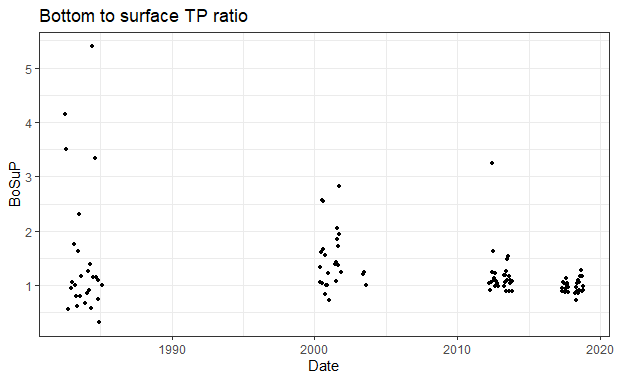

```r
ggplot(data = Seg2_Pdat , aes(x = Date, y = BoSuP))+
  geom_point(size = 1, color = "black")+
  labs(title = "Bottom to surface TP ratio")+
  theme_bw()
```

### 4.3.2 Segment 3

```r
Seg.3_P <- CollectData("Segment3_Pdata.xlsx","report")
Seg3_Praw <- Seg.3_P[[1]]
Seg3_P <- Seg.3_P[[2]]
Seg3_Pdat <- Seg.3_P[[3]]

# Dropping the row 12 due absurdly high value
Seg3_Pdat <- Seg3_Pdat[-12,]

# Segment 3 data frame
head(Seg3_Pdat, n = nrow(Seg3_Pdat))
```

|  | Date | P_conc_Bottom | P_conc_surface | Depth_Bottom | Depth_surface | Average Wind Speed (mph) | Maximum Wind Speed (mph) | AirTemp | SurfaceTemp | WtrTemp_14d | BottomTemp | WtrTemp_35d | TempDiff | BoSuP | level_diff | Bottom_level_diff | Month | Year | Segment |
| --- | --- | --- | --- | --- | --- | --- | --- | --- | --- | --- | --- | --- | --- | --- | --- | --- | --- | --- | --- |
| 1 | 1982-07-14 | 0.27000000 | 0.05000000 | 8.839200 | 1.2192000 | 4.3 | 11.5 | 24.6 | 24.778571 | 27.654174 | 23.9942857 | 23.842053 | 0.78428572 | 5.4000000 | 7.620000 | 5.839200 | 7 | 1982 | 3 |
| 2 | 1982-08-10 | 0.12000000 | 0.04000000 | 8.839200 | 1.2192000 | 6.9 | 9.2 | 25.3 | 25.221429 | 28.103046 | 25.6628571 | 25.315735 | 0.44142857 | 3.0000000 | 7.620000 | 5.839200 | 8 | 1982 | 3 |
| 3 | 1982-09-15 | 0.07000000 | 0.03000000 | 9.753600 | 1.2192000 | 5.2 | 8.1 | 24.6 | 22.571429 | 25.417059 | 23.2342857 | 23.170821 | 0.66285714 | 2.3333333 | 8.534400 | 6.753600 | 9 | 1982 | 3 |
| 4 | 1982-10-04 | 0.05000000 | 0.09000000 | 9.753600 | 0.9144000 | 4.1 | 8.1 | 20.3 | 18.071429 | 20.855949 | 20.9371429 | 21.141985 | 2.86571429 | 0.5555556 | 8.839200 | 6.753600 | 10 | 1982 | 3 |
| 5 | 1982-11-16 | 0.06000000 | 0.06000000 | 7.162800 | 0.9144000 | 4.5 | 6.9 | 4.1 | 10.028571 | 12.703869 | 12.1771429 | 13.405153 | 2.14857143 | 1.0000000 | 6.248400 | 4.162800 | 11 | 1982 | 3 |
| 6 | 1982-12-20 | 0.10000000 | 0.08000000 | 9.753600 | 1.2192000 | 9.1 | 16.1 | 4.0 | 3.969641 | 6.562659 | 8.7551000 | 10.382804 | 4.78545916 | 1.2500000 | 8.534400 | 6.753600 | 12 | 1982 | 3 |
| 7 | 1983-01-13 | 0.09000000 | 0.05000000 | 10.972800 | 1.5240000 | 6.0 | 10.4 | -0.6 | 4.678571 | 7.281216 | 5.4200128 | 7.437255 | 0.74144134 | 1.8000000 | 9.448800 | 7.972800 | 1 | 1983 | 3 |
| 8 | 1983-02-22 | 0.14000000 | 0.06000000 | 11.887200 | 1.5240000 | 5.6 | 11.5 | 11.7 | 4.692857 | 7.295696 | 4.0257143 | 6.205811 | 0.66714286 | 2.3333333 | 10.363200 | 8.887200 | 2 | 1983 | 3 |
| 9 | 1983-03-29 | 0.21000000 | 0.06000000 | 13.716000 | 1.2192000 | 5.0 | 9.2 | 8.8 | 9.178571 | 11.842326 | 9.7447533 | 11.256866 | 0.56618185 | 3.5000000 | 12.496800 | 10.716000 | 3 | 1983 | 3 |
| 10 | 1983-04-28 | 0.07000000 | 0.07000000 | 7.924800 | 1.2192000 | 10.0 | 16.1 | 21.1 | 12.057879 | 14.760735 | 11.7974375 | 13.069797 | 0.26044194 | 1.0000000 | 6.705600 | 4.924800 | 4 | 1983 | 3 |

[output cut: 70 more lines]

```r
NA
```

A plot of bottom to surface TP ratios in Segment 3:

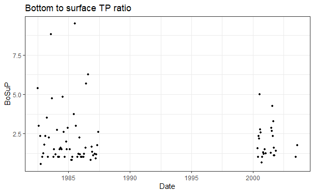

```r
ggplot(data = Seg3_Pdat , aes(x = Date, y = BoSuP))+
  geom_point(size = 1, color = "black")+
  labs(title = "Bottom to surface TP ratio")+
  theme_bw()
```

### 4.3.3 Segment 4

```r
Seg.4_P <- CollectData("Segment4_Pdata.xlsx","report")
Seg4_Praw <- Seg.4_P[[1]]
Seg4_P <- Seg.4_P[[2]]
Seg4_Pdat <- Seg.4_P[[3]]


# Segment 4 data frame
head(Seg4_Pdat, n = nrow(Seg4_Pdat))
```

|  | Date | P_conc_Bottom | P_conc_surface | Depth_Bottom | Depth_surface | Average Wind Speed (mph) | Maximum Wind Speed (mph) | AirTemp | SurfaceTemp | WtrTemp_14d | BottomTemp | WtrTemp_35d | TempDiff | BoSuP | level_diff | Bottom_level_diff | Month | Year | Segment |
| --- | --- | --- | --- | --- | --- | --- | --- | --- | --- | --- | --- | --- | --- | --- | --- | --- | --- | --- | --- |
| 1 | 1982-07-14 | 0.150 | 0.110 | 6.705600 | 0.609600 | 4.3 | 11.5 | 24.6 | 24.778571 | 27.654174 | 23.9942857 | 23.842053 | 0.78428572 | 1.3636364 | 6.096000 | 3.705600 | 7 | 1982 | 4 |
| 2 | 1982-08-10 | 0.100 | 0.100 | 7.924800 | 0.914400 | 6.9 | 9.2 | 25.3 | 25.221429 | 28.103046 | 25.6628571 | 25.315735 | 0.44142857 | 1.0000000 | 7.010400 | 4.924800 | 8 | 1982 | 4 |
| 3 | 1982-09-15 | 0.040 | 0.050 | 5.791200 | 0.914400 | 5.2 | 8.1 | 24.6 | 22.571429 | 25.417059 | 23.2342857 | 23.170821 | 0.66285714 | 0.8000000 | 4.876800 | 2.791200 | 9 | 1982 | 4 |
| 4 | 1982-10-04 | 0.080 | 0.100 | 7.010400 | 0.914400 | 4.1 | 8.1 | 20.3 | 18.071429 | 20.855949 | 20.9371429 | 21.141985 | 2.86571429 | 0.8000000 | 6.096000 | 4.010400 | 10 | 1982 | 4 |
| 5 | 1982-11-16 | 0.150 | 0.110 | 3.048000 | 1.219200 | 4.5 | 6.9 | 4.1 | 10.028571 | 12.703869 | 12.1771429 | 13.405153 | 2.14857143 | 1.3636364 | 1.828800 | 0.048000 | 11 | 1982 | 4 |
| 6 | 1982-12-20 | 0.210 | 0.110 | 8.839200 | 0.609600 | 9.1 | 16.1 | 4.0 | 3.969641 | 6.562659 | 8.7551000 | 10.382804 | 4.78545916 | 1.9090909 | 8.229600 | 5.839200 | 12 | 1982 | 4 |
| 7 | 1983-01-13 | 0.240 | 0.100 | 9.753600 | 0.914400 | 6.0 | 10.4 | -0.6 | 4.678571 | 7.281216 | 5.4200128 | 7.437255 | 0.74144134 | 2.4000000 | 8.839200 | 6.753600 | 1 | 1983 | 4 |
| 8 | 1983-02-22 | 0.100 | 0.140 | 5.998464 | 0.609600 | 5.6 | 11.5 | 11.7 | 4.692857 | 7.295696 | 4.0257143 | 6.205811 | 0.66714286 | 0.7142857 | 5.388864 | 2.998464 | 2 | 1983 | 4 |
| 9 | 1983-03-29 | 0.170 | 0.080 | 10.972800 | 1.219200 | 5.0 | 9.2 | 8.8 | 9.178571 | 11.842326 | 9.7447533 | 11.256866 | 0.56618185 | 2.1250000 | 9.753600 | 7.972800 | 3 | 1983 | 4 |
| 10 | 1983-06-07 | 0.140 | 0.090 | 9.753600 | 1.828800 | 6.9 | 13.8 | 21.1 | 19.885714 | 22.694872 | 18.6657143 | 19.135859 | 1.22000000 | 1.5555556 | 7.924800 | 6.753600 | 6 | 1983 | 4 |

[output cut: 72 more lines]

```r
NA
```

A plot of bottom to surface TP ratios in Segment 4:

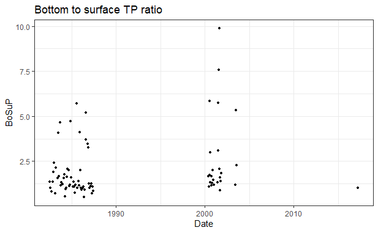

```r
ggplot(data = Seg4_Pdat , aes(x = Date, y = BoSuP))+
  geom_point(size = 1, color = "black")+
  labs(title = "Bottom to surface TP ratio")+
  theme_bw()
```

## 4.4 Combined dataset

### 4.4.1 Calibration dataset

```r
# Seed value
seed.value <- 022022

# fracttion of data for calibration
frctn <- 1

set.seed(seed.value)
N2 <- createDataPartition(Seg2_Pdat$BoSuP, p = frctn, list = FALSE)
N3 <- createDataPartition(Seg3_Pdat$BoSuP, p = frctn, list = FALSE)
N4 <- createDataPartition(Seg4_Pdat$BoSuP, p = frctn, list = FALSE)
SegP_dat <- rbind(Seg2_Pdat[N2,], Seg3_Pdat[N3,])
SegP_dat <- rbind(SegP_dat, Seg4_Pdat[N4,])

# Adding a column with changed units of wind speed (mph to m/s)
SegP_dat$`Average Wind Speed (ms)` <- SegP_dat$`Average Wind Speed (mph)`*0.447
SegP_dat$`Maximum Wind Speed (ms)` <- SegP_dat$`Maximum Wind Speed (mph)`*0.447

# Quick view of the data frame
head(SegP_dat, n = nrow(SegP_dat))
```

|  | Date | P_conc_Bottom | P_conc_surface | Depth_Bottom | Depth_surface | Average Wind Speed (mph) | Maximum Wind Speed (mph) | AirTemp | SurfaceTemp | WtrTemp_14d | BottomTemp | WtrTemp_35d | TempDiff | BoSuP | level_diff | Bottom_level_diff | Month | Year | Segment | Average Wind Speed (ms) | Maximum Wind Speed (ms) |
| --- | --- | --- | --- | --- | --- | --- | --- | --- | --- | --- | --- | --- | --- | --- | --- | --- | --- | --- | --- | --- | --- |
| 1 | 1982-07-14 | 0.29000000 | 0.07000000 | 5.486400 | 1.2192000 | 4.3 | 11.5 | 24.6 | 24.778571 | 27.654174 | 23.9942857 | 23.842053 | 0.78428572 | 4.1428571 | 4.267200 | 2.486400 | 7 | 1982 | 2 | 1.9221 | 5.1405 |
| 2 | 1982-08-10 | 0.21000000 | 0.06000000 | 3.962400 | 0.1005840 | 6.9 | 9.2 | 25.3 | 25.221429 | 28.103046 | 25.6628571 | 25.315735 | 0.44142857 | 3.5000000 | 3.861816 | 0.962400 | 8 | 1982 | 2 | 3.0843 | 4.1124 |
| 3 | 1982-10-04 | 0.05000000 | 0.09000000 | 19.812000 | 0.7620000 | 4.1 | 8.1 | 20.3 | 18.071429 | 20.855949 | 20.9371429 | 21.141985 | 2.86571429 | 0.5555556 | 19.050000 | 16.812000 | 10 | 1982 | 2 | 1.8327 | 3.6207 |
| 4 | 1982-12-20 | 0.09000000 | 0.09500000 | 5.791200 | 1.0668000 | 9.1 | 16.1 | 4.0 | 3.969641 | 6.562659 | 8.7551000 | 10.382804 | 4.78545916 | 0.9473684 | 4.724400 | 2.791200 | 12 | 1982 | 2 | 4.0677 | 7.1967 |
| 5 | 1983-01-13 | 0.08000000 | 0.07500000 | 6.705600 | 1.0668000 | 6.0 | 10.4 | -0.6 | 4.678571 | 7.281216 | 5.4200128 | 7.437255 | 0.74144134 | 1.0666667 | 5.638800 | 3.705600 | 1 | 1983 | 2 | 2.6820 | 4.6488 |
| 6 | 1983-02-22 | 0.15000000 | 0.08500000 | 6.705600 | 0.9144000 | 5.6 | 11.5 | 11.7 | 4.692857 | 7.295696 | 4.0257143 | 6.205811 | 0.66714286 | 1.7647059 | 5.791200 | 3.705600 | 2 | 1983 | 2 | 2.5032 | 5.1405 |
| 7 | 1983-03-29 | 0.09000000 | 0.09000000 | 6.400800 | 1.0668000 | 5.0 | 9.2 | 8.8 | 9.178571 | 11.842326 | 9.7447533 | 11.256866 | 0.56618185 | 1.0000000 | 5.334000 | 3.400800 | 3 | 1983 | 2 | 2.2350 | 4.1124 |
| 8 | 1983-04-28 | 0.06000000 | 0.07500000 | 5.791200 | 1.0668000 | 10.0 | 16.1 | 21.1 | 12.057879 | 14.760735 | 11.7974375 | 13.069797 | 0.26044194 | 0.8000000 | 4.724400 | 2.791200 | 4 | 1983 | 2 | 4.4700 | 7.1967 |
| 9 | 1983-05-11 | 0.05000000 | 0.08000000 | 4.267200 | 1.8288000 | 4.9 | 9.2 | 16.7 | 18.064286 | 20.848709 | 14.7860089 | 15.709303 | 3.27827680 | 0.6250000 | 2.438400 | 1.267200 | 5 | 1983 | 2 | 2.1903 | 4.1124 |
| 10 | 1983-06-07 | 0.09000000 | 0.05500000 | 4.876800 | 1.5240000 | 6.9 | 13.8 | 21.1 | 19.885714 | 22.694872 | 18.6657143 | 19.135859 | 1.22000000 | 1.6363636 | 3.352800 | 1.876800 | 6 | 1983 | 2 | 3.0843 | 6.1686 |

[output cut: 265 more lines]

```r
# Total number of data points
print(paste0("Number of calibration data points: ", nrow(SegP_dat)))
```

```
[1] "Number of calibration data points: 275"
```

```r
# Unique data points
print(paste0("Number of unique dates in the data points: ", length(unique(SegP_dat$Date))))
```

```
[1] "Number of unique dates in the data points: 157"
```

# 5 Training the random forest model

```r
# Creating a vector of features
combo <- c("Date","Average Wind Speed (ms)","BottomTemp","SurfaceTemp","BoSuP", "Month", "Depth_surface", "Depth_Bottom", "Segment")

SegPfac1 <- SegP_dat[,combo]


# renaming
SegPfac1 <- SegPfac1 %>% rename(.,
                                      Average.Wind.Speed.ms = `Average Wind Speed (ms)`)

# Create random forest for regression
set.seed(seed.value)
BoSuP.rf <- randomForest(BoSuP ~ .,
                         data = select(SegPfac1, -Date ),
                         mtry =3,
                         ntree = 1000,
                         importance = TRUE,
                         na.action = na.omit)

# quick model performance
BoSuP.rf
```

```
Call:
 randomForest(formula = BoSuP ~ ., data = select(SegPfac1, -Date),      mtry = 3, ntree = 1000, importance = TRUE, na.action = na.omit)
               Type of random forest: regression
                     Number of trees: 1000
No. of variables tried at each split: 3

          Mean of squared residuals: 1.318645
                    % Var explained: 34.81
```

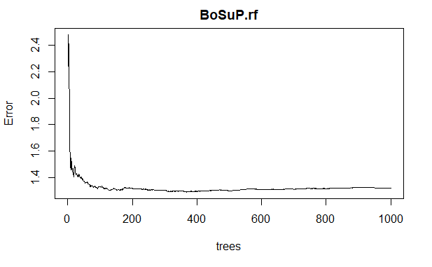

```r
plot(BoSuP.rf)
```

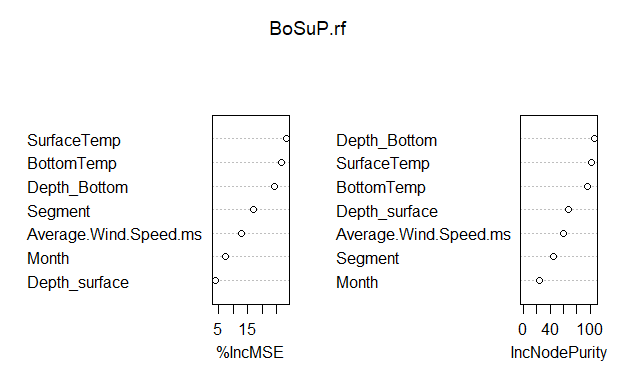

```r
# importance(BoSuP.rf)

varImpPlot(BoSuP.rf)
```

```r
print(paste0("Coefficient of determination: ", VarExp(BoSuP.rf$predicted, BoSuP.rf$y)))
```

```
[1] "Coefficient of determination: 0.348"
```

```r
# test
# SegPfac1_test <- SegP_dat_test[,combo]
# SegPfac1_test <- SegPfac1_test %>% rename(.,
#                                       Average.Wind.Speed.ms = `Average Wind Speed (ms)`)
# pred_vals <- predict(BoSuP.rf, newdata = select(SegPfac1_test, -Date, -BoSuP))
# VarExp(pred_vals,SegPfac1_test$BoSuP)
# plot(pred_vals, SegPfac1_test$BoSuP)
# abline(coef = c(0,1))
```

```r
predicted_BoSuP <- data.frame(obs = BoSuP.rf$y, pred = BoSuP.rf$predicted)

rf_pred_plot <- ggplot()+
  geom_point(data = predicted_BoSuP, aes(x = obs, y = pred))+
  geom_abline( intercept = 0, lty = 2)+
  theme_bw()+
  theme(aspect.ratio = 1,
        legend.background = element_blank(),
        panel.grid.major = element_blank(),
        panel.grid.minor = element_blank(),
        legend.text.align = 0,
        text = element_text(size = 10),
        axis.text = element_text(size = 10),
        legend.text = element_text(size = 10),
        axis.title = element_text(size = 10))+
  labs(x = expression(Observed~R["i,b:s"]),
       y = expression(Predicted~R["i,b:s"]))+
  scale_y_continuous(limits = c(0,5),
                     labels = c("","1.0","2.0","3.0","4.0","5.0"),
                     expand = c(0,0))+
  scale_x_continuous(limits = c(0,10),
                     expand = c(0,0))+
  coord_flip()
rf_pred_plot

# Saving the plot
png(file="OutputFiles/JLPMv016_rf_pred_plot.png",height=4,width=6,units='in',res=1200)
```

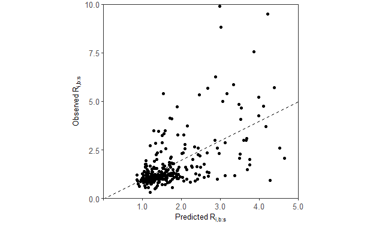

```r
rf_pred_plot
dev.off()
```

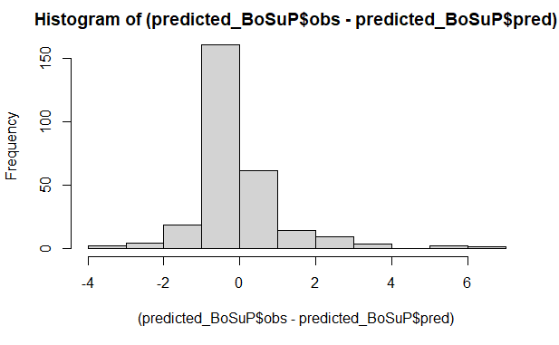

```r
hist((predicted_BoSuP$obs-predicted_BoSuP$pred))
```

# 6 Predicting daily bottom to surface P ratio (1983-2018)

## 6.1 Hypolimnion mid-depth

Now, let us prepare the input data for daily bottom to surface TP ratio prediction using the trained random forest. We will first load and process the data from *HypolimnionCalcs.xlsx* file.

```r
# loading the monthly hypolimnetic depths data
hypo.midDepth.raw <- read_excel("DataFiles/HypolimnionCalcs.xlsx",
                                sheet = "Sheet1", range = "A2:Y434")%>%
  rename(.,
         H1m = `H1 m...22`,
         H2m = `H2 m...23`,
         H3m = `H3 m...24`,
         H4m = `H4 m...25`)

# Only segments 2-4; units in m
hypo.midDepth <- hypo.midDepth.raw[,c("start_d", "H2m", "H3m", "H4m")]

# Create DateTime object for entire duration
p.o.r <- data.frame(start_d = seq(as.Date("1983-01-01"), as.Date("2018-12-31"),  by = "1 day"))

# merging
hypo.midDepth$start_d <- as.Date(hypo.midDepth$start_d) # changing to DateTime type
hypo.midDepth <- merge(p.o.r, hypo.midDepth, by = "start_d", all.x = T)

# Filling the daily values from the monthly values
hypo.midDepth <- na.locf(na.locf(hypo.midDepth), fromLast = T)
```

[output not shown]

The median depth to mid-point of the hypolimnion in each segment is as follows:

```r
sapply(hypo.midDepth[,c(2:4)], median)
```

```
     H2m      H3m      H4m
4.303910 5.027598 5.814690
```

## 6.2 Input data

```r
# Function to arrange the input data
pred_df <- function(sur_dep = 1.5, bot_dep = hypo.midDepth$H2m, combox, x = 2){

  p.o.r <- seq(as.Date("1983-01-01"), as.Date("2018-12-31"),  by = "1 day")
  air.data <- RDU_wind[which(RDU_wind$Date %in% p.o.r), c(1,2)]
  botT.data <- Sim_BotTemp[which(Sim_BotTemp$Date %in% p.o.r), c(1,2)]
  surT.data <- Sim_SurTemp[which(Sim_SurTemp$Date %in% p.o.r), c(1,3)]
  surD.data <- rep(sur_dep, length(p.o.r))
  botD.data <- bot_dep


  # merging the datasets
  pred.data <- merge(air.data, botT.data, by = "Date")
  pred.data <- merge(pred.data, surT.data, by = "Date")

  pred.data <- data.frame(pred.data,
                          Depth_surface = surD.data,
                          Depth_Bottom = botD.data)

  pred.data <- pred.data %>% mutate(TempDiff = abs(SurfaceTemp - BottomTemp),
                                    level_diff = Depth_Bottom -Depth_surface,
                                    Month = month(Date),
                                    Segment = rep(x, length(p.o.r)))

  # Adding a column for wind speed in ms
  pred.data$Average.Wind.Speed..ms. <- pred.data$Average.Wind.Speed..mph.*0.447

  pred.data <- pred.data %>% rename(.,
                                  Average.Wind.Speed.ms = Average.Wind.Speed..ms.)

  pred.data <- pred.data[,combox]

  pred.data <- pred.data %>% drop_na()

  return(pred.data)
}

# Creating a vector of input features
pred_combo <- c("Date","Average.Wind.Speed.ms", "BottomTemp","SurfaceTemp", "Month", "Depth_surface", "Depth_Bottom", "Segment")

# Segment 2
pred.data.2 <- pred_df(1.5,hypo.midDepth$H2m, pred_combo,2)

# Segment 3
pred.data.3 <- pred_df(1.5,hypo.midDepth$H3m, pred_combo,3)

# Segment 4
pred.data.4 <- pred_df(1.5,hypo.midDepth$H4m, pred_combo,4)
```

## 6.3 Simulated data for each segment

```r
# Function to generate simulated data for each segment
sim_data<- function(p_dat = pred.data.2, segNo = Seg2_Pdat){
  pred_vals <- predict(BoSuP.rf, newdata = select(p_dat, -Date))
  p_dat <- cbind(p_dat, pred_BoSuP = pred_vals)

  # Adding the observed data
  p_dat <- merge(p_dat,  segNo[, c("Date", "BoSuP")], by = "Date", all.x = T)
  return(p_dat)
}

# Segment 2
pred.data.2 <- sim_data()

# Segment 3
pred.data.3 <- sim_data(pred.data.3, Seg3_Pdat)


# Segment 4
pred.data.4 <- sim_data(pred.data.4, Seg4_Pdat)
```

## 6.4 Segmentwise prediction efficiency

### 6.4.1 Segment 2

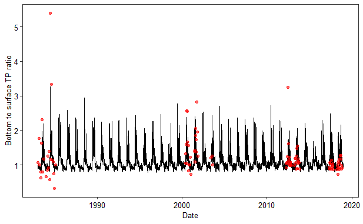

```r
ggplot(data = pred.data.2)+
  geom_line(aes(x = Date,
                y = pred_BoSuP))+
  geom_point(aes(x = Date,
                 y = BoSuP), color = "red", alpha = 0.6)+
  theme_bw()+
  theme(panel.grid.major = element_blank(),
        panel.grid.minor = element_blank(),
        legend.text.align = 0,
        text = element_text(size = 10),
        legend.text = element_text(size = 10, color = "black"),
        axis.title = element_text(size = 10, color = "black"),
        axis.text = element_text(size = 10, color = "black"))+
  scale_y_continuous("Bottom to surface TP ratio")
```

### 6.4.2 Segment 3

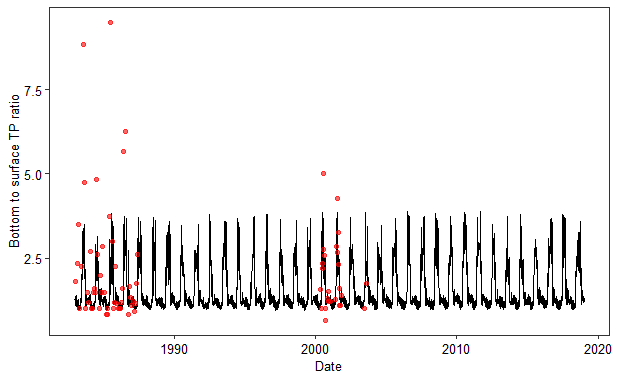

```r
ggplot(data = pred.data.3)+
  geom_line(aes(x = Date,
                y = pred_BoSuP))+
  geom_point(aes(x = Date,
                 y = BoSuP), color = "red", alpha = 0.6)+
  theme_bw()+
  theme(panel.grid.major = element_blank(),
        panel.grid.minor = element_blank(),
        legend.text.align = 0,
        text = element_text(size = 10),
        legend.text = element_text(size = 10, color = "black"),
        axis.title = element_text(size = 10, color = "black"),
        axis.text = element_text(size = 10, color = "black"))+
  scale_y_continuous("Bottom to surface TP ratio")
```

### 6.4.3 Segment 4

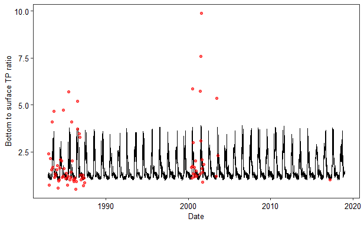

```r
ggplot(data = pred.data.4)+
  geom_line(aes(x = Date,
                y = pred_BoSuP))+
  geom_point(aes(x = Date,
                 y = BoSuP), color = "red", alpha = 0.6)+
  theme_bw()+
  theme(panel.grid.major = element_blank(),
        panel.grid.minor = element_blank(),
        legend.text.align = 0,
        text = element_text(size = 10),
        legend.text = element_text(size = 10, color = "black"),
        axis.title = element_text(size = 10, color = "black"),
        axis.text = element_text(size = 10, color = "black"))+
  scale_y_continuous("Bottom to surface TP ratio")
```

# 7 Seasonal median

```r
# Predicted dataframe
pred.data <- rbind(pred.data.2, pred.data.3)
pred.data <- rbind(pred.data, pred.data.4)

# Adding column for season
pred.data1 <- pred.data
pred.data <- pred.data %>%
  mutate(Season = ifelse(Month%in%c(12,1:5), 1, ifelse(Month%in%c(6:8),2,3)))

# Seasonal median
pred.data.med <-pred.data %>% group_by(Segment, Season) %>% summarise(median = median(pred_BoSuP),
                                                                              count = n())
pred.data.med <- select(pred.data.med, -count)

pred.data.med$median <- round(pred.data.med$median,1)
pred.data.med <- spread(pred.data.med, key = Season, value = median)

kable(pred.data.med) %>% kable_styling(full_width = T)
```

| Segment | 1 | 2 | 3 |
| --- | --- | --- | --- |
| 2 | 0.9 | 1.2 | 1.1 |
| 3 | 1.1 | 2.4 | 1.3 |
| 4 | 1.2 | 2.2 | 1.4 |

```r
# Alternate seasonal median
pred.data1 <- pred.data1 %>%
  mutate(Season = ifelse(Month%in%c(1:3), 1, ifelse(Month%in%c(4:6),2,ifelse(Month%in%c(7:9),3,4))))

pred.data1.med <-pred.data1 %>% group_by(Segment, Season) %>% summarise(median = median(pred_BoSuP),
                                                                              count = n())
pred.data1.med <- select(pred.data1.med, -count)

pred.data1.med$median <- round(pred.data1.med$median,1)
pred.data1.med <- spread(pred.data1.med, key = Season, value = median)

kable(pred.data1.med) %>% kable_styling(full_width = T)
```

| Segment | 1 | 2 | 3 | 4 |
| --- | --- | --- | --- | --- |
| 2 | 0.9 | 1.0 | 1.2 | 1.0 |
| 3 | 1.2 | 1.1 | 2.3 | 1.2 |
| 4 | 1.2 | 1.1 | 2.2 | 1.3 |

```r
# overall seasonal range
pred.data1_ove <- pred.data1 %>% group_by(Season) %>% summarise(Avg = mean(pred_BoSuP),
                                                                med = median(pred_BoSuP),
                                                                min = min(pred_BoSuP),
                                                                max = max(pred_BoSuP))
```

# 8 Saving the files

```r
# Saving the workspace
# save.image("RWorkSpaces/JLPMv016p004_1.RData")
```

```r
# Start timer
End_timer4 <- Sys.time()

# Total time taken to run the entire notebook
Tot_time4 <- End_timer4 - Start_timer4
Tot_time4
```

```
Time difference of 9.99583 secs
```

Although these files were originally saved from Additional025_Stratification_v02082022_RF4.Rmd, we copy the related codes into this notebook as well.

```r
# saving Segment 2 simulated data
# write.csv(pred.data.2, "DataFiles/predBoSuP_Seg2RF4.csv", append = FALSE)

# saving Segment 3 simulated data
# write.csv(pred.data.3, "DataFiles/predBoSuP_Seg3RF4.csv", append = FALSE)

# saving Segment 4 simulated data
# write.csv(pred.data.4, "DataFiles/predBoSuP_Seg4RF4.csv", append = FALSE)
```